# INSAN Grave no Ceará

Modelos de previsão a partir de dados do CadÚnico

J. Victor Batista — Assessor Técnico | DISOC – IPECE

junho de 2026

# Objetivo

Qual é o tamanho do impacto do Cartão Ceará Sem Fome na **probabilidade** dos beneficiários estarem em Insegurança Alimentar e Nutricional Grave?

# Fundamentação: CADINSAN, do MDS

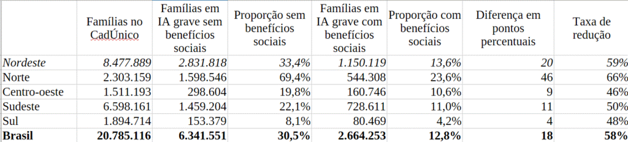

Resultados do CadInsan com e sem benefícios sociais

# Metodologia

Treinar um modelo preditivo com dados da PNAD Contínua e aplicar os estimadores encontrados na população do CadÚnico beneficiada com o Cartão Ceará Sem Fome. O resultado será uma previsão do domicílio com aquelas características estar ou não em INSAN Grave.

## Dados

- PNAD Contínua 2024, 4º trimestre: Informações socioeconômicas e sobre a segurança alimentar dos domicílio. Utilizou-se somente informações do Ceará.
- CadÚnico: Base com beneficiários do Cartão Ceará Sem Fome. A variável de renda é utilizada de duas formas: primeiro sem o valor do Cartão e depois com ele.

# Variáveis utilizadas

Tabela 1: Indicadores utilizados como variáveis independentes no modelo

| Indicador | Variável na PNAD Contínua 2024 |
| --- | --- |
| Renda domiciliar per capita | elaborada a partir da variável VDI5008 |
| Sexo da pessoa de referência | V2007 |
| Cor/raça da pessoa de referência | V2010 |
| Presença de pessoa menor de 6 anos | elaborada a partir da variável V2009 |
| Nível educacional da pessoa de referência | elaborada a partir da variável VD3004 |

Tabela 1: Indicadores utilizados como variáveis independentes no modelo

| Indicador | Variável na PNAD Contínua 2024 |
| --- | --- |
| Situação do domicílio (urbano/rural) | V1022 |
| Presença de trabalhador da agricultura familiar | elaborada a partir da variável VD4007 |
| Dummy de região metropolitana | elaborada a partir da variável Estrato |

# Resultados

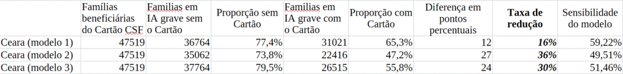

Resultados do Cartão CSF

# Principais conclusões

## Limitações

Os números apresentados são uma medição da probabilidade de Insan, por isso devem ser interpretados com cautela. O presente trabalho é um exercício estatístico a partir de dados administrativos do IBGE e do CadÚnico e tem muito a ganhar caso haja um acompanhamento e coleta primária de dados com os próprios beneficiários do Cartão CSF.

## Próximos passos

Outros exercícios podem ser realizados, como calcular diferentes valores para o cartão e ver como eles alteram a probabilidade de Insan grave.

## Referências

BRASIL, Ministério do Desenvolvimento e Assistência Social, Família e Combate à Fome. **CADINSAN**: indicador de risco de insegurança alimentar municipal a partir dos dados do cadunico. Brasilía, 2025. Disponível em https://www.gov.br/mds/pt-br/Sisan/monitoramento-da-san/Relatorio_CadINSAN.pdf Acesso em jan/2026.

### Obrigado

**João Victor Batista Lopes**  
Assessor Técnico | DISOC – IPECE

*Dados abertos · Código aberto · Ciência reprodutível*